# Yandex project #8 Restaurant Analysis

Goal: To investigate data on various chain and non-chain food establisments, main restaurant streets, seats amount and find dependancies.

Step 1. General Information and preprocessing  
Step 2. Data analysis

- 1. The proportions of the various types of establishments
- 2. The proportions of chain and nonchain establishments
- 3. Which type of establishment is typically a chain?
- 4. What characterizes chains
- 5. The average number of seats for each type of restaurant
- 6. Top ten streets by number of restaurants
- 7. The number of streets that only have one restaurant
- 8. The distribution of the number of seats for the main restaurant streets

Step 3. Overall project conclusion

Presentation: https://drive.google.com/file/d/1KuDIGVOjzA4JGsjc0rLMLJtGyBRdQx2N/view?usp=sharing

### Step 1. General Information and preprocessing

```python
import plotly.express as px
from plotly import graph_objects as go
import pandas as pd
import numpy as np
import matplotlib.pyplot as plt
from matplotlib.pyplot import figure
from scipy import stats as st
import seaborn as sns
import re

rest_data = pd.read_csv(r'C:\Users\RoG\Desktop\Yandex_Course\rest_data_us.csv')
rest_data.head()
```

|  | id | object_name | address | chain | object_type | number |
| --- | --- | --- | --- | --- | --- | --- |
| 0 | 11786 | HABITAT COFFEE SHOP | 3708 N EAGLE ROCK BLVD | False | Cafe | 26 |
| 1 | 11787 | REILLY'S | 100 WORLD WAY # 120 | False | Restaurant | 9 |
| 2 | 11788 | STREET CHURROS | 6801 HOLLYWOOD BLVD # 253 | False | Fast Food | 20 |
| 3 | 11789 | TRINITI ECHO PARK | 1814 W SUNSET BLVD | False | Restaurant | 22 |
| 4 | 11790 | POLLEN | 2100 ECHO PARK AVE | False | Restaurant | 20 |

```python
rest_data.info()
```

```
<class 'pandas.core.frame.DataFrame'>
RangeIndex: 9651 entries, 0 to 9650
Data columns (total 6 columns):
 #   Column       Non-Null Count  Dtype
---  ------       --------------  -----
 0   id           9651 non-null   int64
 1   object_name  9651 non-null   object
 2   address      9651 non-null   object
 3   chain        9648 non-null   object
 4   object_type  9651 non-null   object
 5   number       9651 non-null   int64
dtypes: int64(2), object(4)
memory usage: 452.5+ KB
```

```python
rest_data.duplicated().value_counts()
```

```
False    9651
dtype: int64
```

```python
rest_data.number.describe()
```

```
count    9651.000000
mean       43.695161
std        47.622874
min         1.000000
25%        14.000000
50%        27.000000
75%        46.000000
max       229.000000
Name: number, dtype: float64
```

`Drop the NaN values:`

```python
nanchain = rest_data.query('chain != chain')
rest_data = rest_data.drop(nanchain.index)
```

`Let's strip the address column to street name:`

```python
rest_data['street_name'] = rest_data['address'].replace('(^[0-9]+)','',regex=True).replace('[0-9 #]+$','',regex=True)
```

```python
rest_data.columns= ['id', 'object_name', 'address', 'chain', 'type', 'seats', 'street_name']
```

```python
rest_data['type'].value_counts()
```

```
Restaurant    7253
Fast Food     1066
Cafe           435
Pizza          319
Bar            292
Bakery         283
Name: type, dtype: int64
```

```python
rest_data['chain'] = rest_data.chain.astype(str)
rest_data['chain'] = rest_data['chain'].str.replace('True', 'Chain',regex=True).str.replace('False', 'Non-chain',regex=True)
rest_data
```

|  | id | object_name | address | chain | type | seats | street_name |
| --- | --- | --- | --- | --- | --- | --- | --- |
| 0 | 11786 | HABITAT COFFEE SHOP | 3708 N EAGLE ROCK BLVD | Non-chain | Cafe | 26 | N EAGLE ROCK BLVD |
| 1 | 11787 | REILLY'S | 100 WORLD WAY # 120 | Non-chain | Restaurant | 9 | WORLD WAY |
| 2 | 11788 | STREET CHURROS | 6801 HOLLYWOOD BLVD # 253 | Non-chain | Fast Food | 20 | HOLLYWOOD BLVD |
| 3 | 11789 | TRINITI ECHO PARK | 1814 W SUNSET BLVD | Non-chain | Restaurant | 22 | W SUNSET BLVD |
| 4 | 11790 | POLLEN | 2100 ECHO PARK AVE | Non-chain | Restaurant | 20 | ECHO PARK AVE |
| ... | ... | ... | ... | ... | ... | ... | ... |
| 9646 | 21432 | HALL OF JUSTICE | 217 W TEMPLE AVE | Non-chain | Restaurant | 122 | W TEMPLE AVE |
| 9647 | 21433 | FIN-MELROSE | 5750 MELROSE AVE | Non-chain | Restaurant | 93 | MELROSE AVE |
| 9648 | 21434 | JUICY WINGZ | 6741 HOLLYWOOD BLVD | Chain | Fast Food | 15 | HOLLYWOOD BLVD |
| 9649 | 21435 | MEDIDATE COFFEE | 548 S SPRING ST STE 100 | Non-chain | Cafe | 6 | S SPRING ST STE |
| 9650 | 21436 | CAFE SPROUTS | 1300 S SAN PEDRO ST STE 111 | Chain | Restaurant | 19 | S SAN PEDRO ST STE |

9648 rows × 7 columns

`Dealing with object names, removing chain restaurant ID, fixing some naming issues:`

```python
rest_data['object_name'] = rest_data['object_name'].str.replace('&','AND', regex=True)
```

```python
rest_data['object_name'] = rest_data['object_name'].str.replace('INC.','INC', regex=True)
```

```python
chain_df = rest_data.query('chain == True')
names = chain_df.groupby('object_name', as_index=False).count().sort_values(by='id', ascending=False).query('id > 2')['object_name'].tolist()#.head(30)
for n in names: #bring every obect name to a standart chain name
    rest_data['object_name'] = rest_data['object_name'].apply(lambda x: n if n in x else x)
```

### Step 2. Data analysis

1. Investigate the proportions of the various types of establishments. Plot a graph.

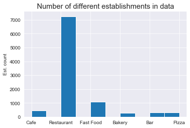

```python
sns.set_style("dark")
rest_data['type'].hist()#.plot(kind='pie', y='type')
plt.ylabel('Est. count')
plt.title('Number of different establishments in data', fontsize=15)
```

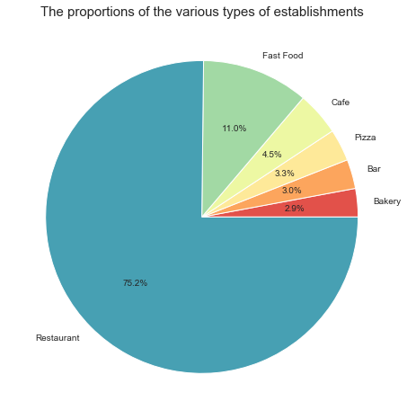

```python
sns.set_palette('Spectral')
rest_data.groupby('type').count().sort_values(by='id').plot(kind='pie', y='id', autopct='%1.1f%%', figsize=(8,8), legend=False)
plt.ylabel('')
plt.title('The proportions of the various types of establishments', fontsize=15)
```

`As we see from the plots above, the restaurants are the most popular type of establishment, dominating the market with 75%.`

1. Investigate the proportions of chain and nonchain establishments. Plot a graph.

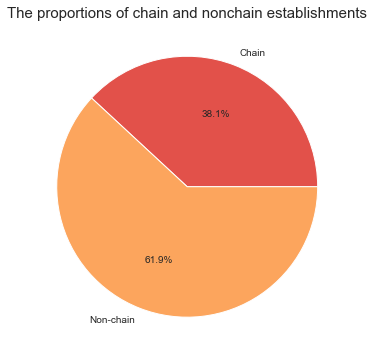

```python
rest_data.groupby('chain').count().plot(kind='pie', y='id', autopct='%1.1f%%', figsize=(6,6), legend=False)
plt.ylabel('')
plt.title('The proportions of chain and nonchain establishments', fontsize=15)
```

`Chain establishments are represented with 38% share.`

1. Which type of establishment is typically a chain?

```python
rest_data['total'] = rest_data['seats'] - 2
```

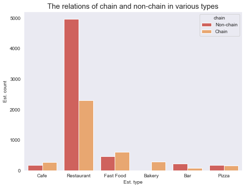

```python
plt.figure(figsize=(8,6))
sns.countplot(x='type', hue='chain', data=rest_data)
#sns.countplot(x='total', hue='chain', data=rest_data)
plt.xlabel('Est. type')
plt.ylabel('Est. count')
plt.title('The relations of chain and non-chain in various types', fontsize=15)
```

`Bakeries, cafe and fast food establishments are more likely to be a unit of chain.`

1. What characterizes chains: many establishments with a small number of seats or a few establishments with a lot of seats?

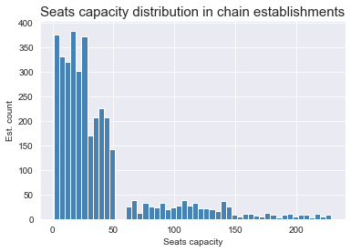

```python
sns.set_palette('tab10')
rest_data.query('chain == "Chain"').seats.hist(bins=50, color='steelblue')
plt.xlabel('Seats capacity')
plt.ylabel('Est. count')
plt.title('Seats capacity distribution in chain establishments', fontsize=15)
```

```python
less_50 = rest_data.query('chain == "Chain" and seats > 50').seats.count() / len(rest_data.query('chain == "Chain"'))
print('Only {:.1%} of chain objects have more than 50 seats.'.format(less_50))
```

```
Only 17.5% of chain objects have more than 50 seats.
```

`The histogram above shows the distribution of seats number in chain establishments. The distribution is uneven - there is a lot of places with up to 50 seats, and only a small part have more than 50, and a gap after 50 seats is there, probably as a consequence of some law restriction. Also the same chain might have both small and large restaurants.`

```python
obj = rest_data.query('chain == "Chain"').groupby('object_name').agg({'id' : 'count', 'seats' : 'mean'})
obj.columns = ['objects', 'seats']
small_est = len(obj.query('objects >= 2')) / len(obj)
print('Only {:.2%} of chain objects may be considered as a large restaurant that is part of a chain.'.format(small_est))
```

```
Only 17.99% of chain objects may be considered as a large restaurant that is part of a chain.
```

```python
print('Seats average for the small restaurants (that are part of a chain):', obj.query('objects == 1').seats.mean(),
      '\nSeats average for hte large restaurants (that are part of a chain):', obj.query('objects > 1').seats.mean())
```

```
Seats average for the small restaurants (that are part of a chain): 42.407953529937444
Seats average for hte large restaurants (that are part of a chain): 37.16362839280613
```

`The mean seats number differs for small and large restaurants. Let's check the difference for statistical significance:`

$H_{0}$ - There is no statistically significant difference between average seats number between large and small chain restaurants.  
$H_{a}$ - The average seats number is different between small and large chain restaurants.  
Significance level $\alpha$ = 0.5

```python
sampleA = obj.query('objects == 1').seats
sampleB = obj.query('objects > 1').seats
print('p-value', "{0:.3f}".format(st.mannwhitneyu(sampleA, sampleB).pvalue))
```

[output not shown]

```python
obj.objects.value_counts().sort_values()
```

```
47       1
31       1
11       1
15       1
14       2
7        2
9        2
13       2
8        4
12       4
10       4
6       10
5       14
4       22
3       68
2      353
1     2238
Name: objects, dtype: int64
```

`Almost all of the chain establishments in the dataset are represented by only one object. Let's call these a "Small chain", and categorize all the others as "Large chains".`

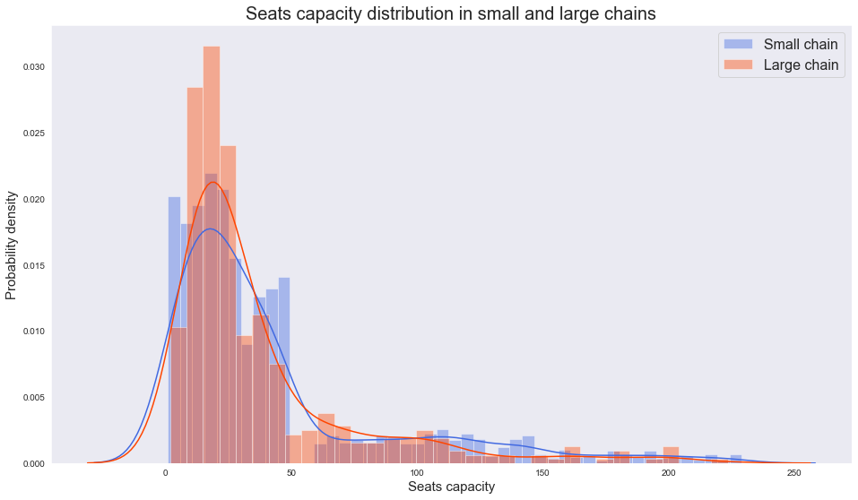

```python
obj['chain_size'] = obj['objects'].apply(lambda x: 'Small chain' if (x < 2) else 'Large chain')
plt.figure(figsize=(16,9))
obj_small = obj.loc[obj['chain_size'] == 'Small chain']
obj_large = obj.loc[obj['chain_size'] == 'Large chain']

sns.distplot(obj_small['seats'], hist=True, label='Small chain', color='royalblue')
sns.distplot(obj_large['seats'], hist=True, label='Large chain', color='orangered')
plt.xlabel('Seats capacity', fontsize=15)
plt.ylabel('Probability density', fontsize=15)
plt.title('Seats capacity distribution in small and large chains', fontsize=20)
plt.legend(prop={'size': 16})
plt.show()
```

`From a distribution plot above we may conclude that large chains tend to keep number of seats low and small chains seats count is higher.`

1. Determine the average number of seats for each type of restaurant. On average, which type of restaurant has the greatest number of seats? Plot graphs.

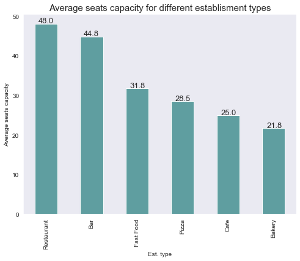

```python
avg_seats = rest_data.groupby('type').agg({'seats' : 'mean'}).sort_values(by='seats', ascending=False)
ax = avg_seats.plot(kind='bar', color='cadetblue', legend=False, figsize=(8,6))
plt.xlabel('Est. type')
plt.ylabel('Average seats capacity')
plt.title('Average seats capacity for different establisment types', fontsize=15)
for p in ax.patches:
    ax.annotate(str(round(p.get_height(), 1)), (p.get_x() * 1.005 + 0.075, p.get_height() * 1.005), fontsize=13)
```

`Restaurants have the biggest average number of seats - 48.`

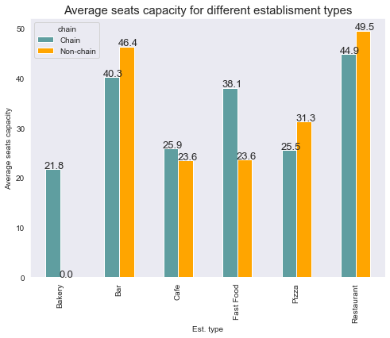

```python
#avg_seats_chain = rest_data.groupby(['type', 'chain']).agg({'seats' : 'mean'})#.sort_values(by='seats', ascending=False)
avg_seats_chain = rest_data.pivot_table(index='type', columns='chain', values='seats', aggfunc='mean')
ax = avg_seats_chain.plot(kind='bar', legend=True, color=['cadetblue', 'orange'],figsize=(8,6))
plt.xlabel('Est. type')
plt.ylabel('Average seats capacity')
plt.title('Average seats capacity for different establisment types', fontsize=15)
for p in ax.patches:
    ax.annotate(str(round(p.get_height(), 1)), (p.get_x() - 0.015, p.get_height() * 1.005), fontsize=13)
```

`Chain and non-chain average number of seats diiffers, non-chain bars, pizzas and restaurants have more seats, cafes and fast foods have less.`

1. Put the data on street names from the address column in a separate column.
2. Plot a graph of the top ten streets by number of restaurants.

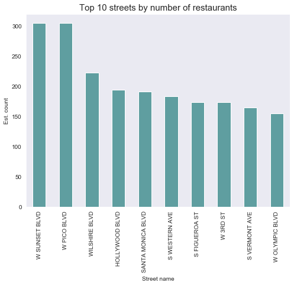

```python
streets = rest_data.groupby(['street_name']).count().sort_values(by='id', ascending=False)
streets.head(10)['id'].plot(kind='bar', color='cadetblue', figsize=(8,6))
plt.xlabel('Street name')
plt.ylabel('Est. count')
plt.title('Top 10 streets by number of restaurants', fontsize=15)
```

`W Sunset Blvd and W Pico Blvd are the top streets with the most establishments there.`

1. Find the number of streets that only have one restaurant.

```python
print(len(streets.query('id == 1')))
print(len(streets.query('id == 1'))/len(streets))
```

```
1213
0.662117903930131
```

`There are 1213 (66%) streets with only one restaurant on it.`

1. For streets with a lot of restaurants, look at the distribution of the number of seats. What trends can you see?

`Let's assume that main streets are the streets at the top of our streets list, sorted by restaurants number:`

```python
streets_list_main = streets.head(100).index.to_list()
streets_list_perif = streets.tail(100).index.to_list()
```

```python
streets_main_rest = rest_data.query('street_name == @streets_list_main')
streets_main_perif = rest_data.query('street_name == @streets_list_perif')
```

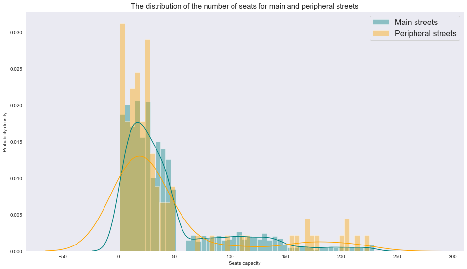

```python
plt.figure(figsize=(16,9))
sns.distplot(streets_main_rest['seats'], bins=50, label='Main streets', color='teal')
sns.distplot(streets_main_perif['seats'], bins=50, label='Peripheral streets', color='orange')
plt.legend(prop={'size': 16})
plt.xlabel('Seats capacity')
plt.ylabel('Probability density')
plt.title('The distribution of the number of seats for main and peripheral streets', fontsize=15)
```

`The biggest difference we see on the distplot above is that there's more restaurants on the main streets within the range of 30-50 and 60-150 seats. It looks like this is optimal seats range for a main street restaurant to fit the customers.`

### Step3. Overall conclusion

Restaurants are dominating the market with 75%. On the main streets a succesful small establishment should fit 30-50 people, and medium size establishment should fit 60-150, on peripheral street it is more likely to have up to 30 seats or more than 150. Depending on the restaurant type, there are different seats options: bars and restaurants should have maximum seats capacity, since clients spend there more time. Bars and restaurants are less likely to be a part of a chain. Cafes, fast foods and bakeries are usually a chain establishments.